# regresion

Cristian Sáez Mardones

18-01-2021

# Regresión lineal costos medicos

[Data set original](https://www.kaggle.com/mirichoi0218/insurance)

Columns

- age: age of primary beneficiary
- sex: insurance contractor gender, female, male
- bmi: Body mass index, providing an understanding of body, weights that are relatively high or low relative to height, objective index of body weight (kg / m ^ 2) using the ratio of height to weight, ideally 18.5 to 24.9
- children: Number of children covered by health insurance / Number of dependents
- smoker: Smoking
- region: the beneficiary’s residential area in the US, northeast, southeast, southwest, northwest.
- charges: Individual medical costs billed by health insurance
- Diremos que el modelo es aceptable si explica sobre un 85% de los datos
- Diremos que el modelo es bueno si explica sobre un 90% de los datos

Cargamos los datos

```r
df = read.csv('insurance.csv')
head(df)
```

```
##   age    sex    bmi children smoker    region   charges
## 1  19 female 27.900        0    yes southwest 16884.924
## 2  18   male 33.770        1     no southeast  1725.552
## 3  28   male 33.000        3     no southeast  4449.462
## 4  33   male 22.705        0     no northwest 21984.471
## 5  32   male 28.880        0     no northwest  3866.855
## 6  31 female 25.740        0     no southeast  3756.622
```

```r
dim(df)
```

```
## [1] 1338    7
```

```r
train <- df[c(1:1150), ]
test <- df[c(1151:dim(df)[1]), ]
```

Gráfica de la predicción de edad vs precio

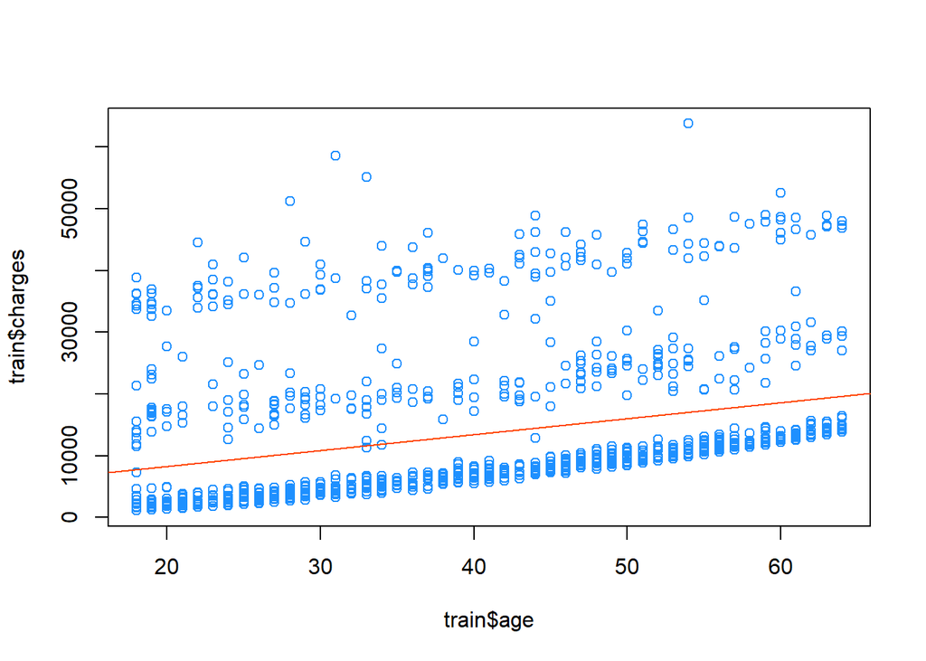

```r
plot(train$age, train$charges, col='dodgerblue')
abline(lm(charges~age, data=train), col="orangered")
```

```r
summary(lm(charges~age, data=train))$r.squared
```

```
## [1] 0.09208437
```

Agregamos el bmi

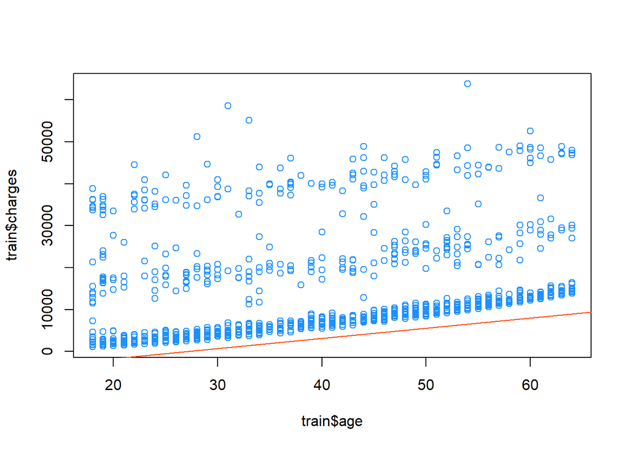

```r
plot(train$age, train$charges, col='dodgerblue')
abline(lm(charges~age+bmi, data=train), col="orangered")
```

```r
summary(lm(charges~age+bmi, data=train))$r.squared
```

```
## [1] 0.1201702
```

Buscamos el mejor modelo

```r
summary(lm(charges~age+bmi+region, data=train))$r.squared
```

```
## [1] 0.1249509
```

```r
summary(lm(charges~age+bmi+region+smoker, data=train))$r.squared
```

```
## [1] 0.7507419
```

```r
summary(lm(charges~age+bmi+region+smoker+sex, data=train))$r.squared
```

```
## [1] 0.7508625
```

```r
summary(lm(charges~age+bmi+region+smoker+sex+children, data=train))$r.squared
```

```
## [1] 0.7520346
```

Nos quedamos con el modelo que incluye todas las variables

```r
model <- lm(charges~age+bmi+region+smoker+sex+children, data=train)
prediction_y <- predict(model, test)
correlacion <- cor(test$charges, prediction_y)
```